# QMSS G5072 Homework 6

Ting An Lai

2019-10-27

# Working with Strings

### 1. Scrabble

For our first exercise, we will brush up on our Scrabble board game knowledge a bit.

Follow the code below to download a scrabble world list.

```r
if (!require("stringr")) install.packages('stringr')
if (!require("stringi")) install.packages('stringi')
if (!require("ScrabbleScore")) install.packages('ScrabbleScore')
library(stringr)
library(stringi)
library(ScrabbleScore)
data(twl06)
scrabble <- twl06
```

#### a) Words with `z`

Select all words that contain at least one `z`. Among the z-words, tabulate how many `z`’s the words contain (i.e. how many words contain one `z`, two `z`’s etc.).

```r
table(number_z)
```

```
number_z
     0      1      2      3      4
171567   6677    424     16      7
```

#### b) Word lengths

Provide a histogram of the word lengths in the scrabble dictionary.

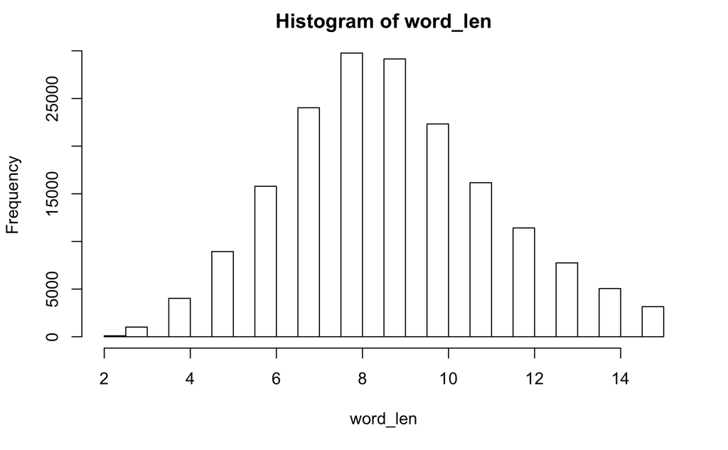

#### c) Vowels

How many words both start and end with a vowel?

```r
str_subset(twl06, pattern = "^[a|e|i|o|u|A|E|I|O|U].*(a|e|i|o|u|A|E|I|O|U)$") %>%
  length()
```

```
[1] 5075
```

#### d) Longest word with `New York`

What is the longest scrabble word that can be formed just out of the letters contained in “New York” (repetitions of letters are allowed)?

```r
str(a)
```

```
 chr [1:151] "eek" "eery" "eke" "en" "enow" "eon" "er" "ere" "erenow" ...
```

#### e) Consonants only

Find the word(s) with the largest number of consecutive consonants.

```r
vowels <- "[aeiouAEIOU]"
not_vowels <- "[^aeiouAEIOU]"


replace_vowel <- str_replace_all(twl06, vowels, " " )

c <- str_split(replace_vowel, " ", simplify = TRUE)
longest_not_vowel <- c[str_length(c) == sort (str_length(c), decreasing = TRUE)[1]]
print (longest_not_vowel)
```

```
[1] "dysrhythm" "dysrhythm" "dysrhythm" "lyrhythms" "lfhydryls"
```

```r
print (str_subset(twl06, pattern = ".*dysrhythm.*"))
```

```
[1] "dysrhythmia"  "dysrhythmias" "dysrhythmic"
```

```r
print (str_subset(twl06, pattern = ".*lyrhythms.*"))
```

```
[1] "polyrhythms"
```

```r
print (str_subset(twl06, pattern = ".*lfhydryls.*"))
```

```
[1] "sulfhydryls"
```

#### f) Bonuzz (*optional*)

Find the z-word(s) with z’s that are as far apart as possible (i.e. we are interested in the distance between any two z’s in the word). That means the word could contain more than two z’s.

```r
str_subset (zz_words, pattern = 'zuz' )
```

```
[1] "mezuza"   "mezuzah"  "mezuzahs" "mezuzas"  "mezuzot"  "mezuzoth"
[7] "zuz"      "zuzim"
```

### 2. Emergency Hospital Injuries

The file `emergency.csv` contains a random sample of 10,000 narratives of injuries treated in U.S. emergency departments. We will try to extract some structured data from these narratives.

```r
library(tidyverse)
emer_data <- read_csv('/Users/tinganlai/Documents/GitHub/Lai_Ting_An/hw06/emergency.csv')
```

#### a) Fractures

Find all narratives related to “fractures”. Try to include singular/plural/verb forms in your search. How many fracture narratives can you find?

```r
#View (emer_data)

str(emer_data)
```

```
Classes ‘spec_tbl_df’, ‘tbl_df’, ‘tbl’ and 'data.frame':    9999 obs. of  1 variable:
 $ 10 MO F FELL OUT OF SHOPPING CART;DX FRACTURED SKULL: chr  "75YOF WITH LAC TO FINGER FROM METAL CAN" "8YOF FRACTURED FINGER FELL OFF HER BIKE" "9 YOM TACKLED DURING FOOTBALL PRACTICE.  DX: CONCUSSION." "PT WAS HIT ON RT SIDE WHILE PLAYING FOOTBALL DX: CHI" ...
 - attr(*, "spec")=
  .. cols(
  ..   `10 MO F FELL OUT OF SHOPPING CART;DX FRACTURED SKULL` = col_character()
  .. )
```

```r
emer_df <- as.data.frame(emer_data)
str(emer_df)
```

```
'data.frame':   9999 obs. of  1 variable:
 $ 10 MO F FELL OUT OF SHOPPING CART;DX FRACTURED SKULL: chr  "75YOF WITH LAC TO FINGER FROM METAL CAN" "8YOF FRACTURED FINGER FELL OFF HER BIKE" "9 YOM TACKLED DURING FOOTBALL PRACTICE.  DX: CONCUSSION." "PT WAS HIT ON RT SIDE WHILE PLAYING FOOTBALL DX: CHI" ...
 - attr(*, "spec")=
  .. cols(
  ..   `10 MO F FELL OUT OF SHOPPING CART;DX FRACTURED SKULL` = col_character()
  .. )
```

```r
is.character(emer_df$`10 MO F FELL OUT OF SHOPPING CART;DX FRACTURED SKULL`)
```

```
[1] TRUE
```

```r
fractures <- str_detect(emer_df$`10 MO F FELL OUT OF SHOPPING CART;DX FRACTURED SKULL` , ".*[F|f][R|r][A|a][C|c][T|t][U|u][R|r].*")
p <- emer_df$`10 MO F FELL OUT OF SHOPPING CART;DX FRACTURED SKULL`[fractures==TRUE]
length(p)
```

```
[1] 531
```

```r
#View (p)
#531 fractuer narratives
```

#### c) Body Parts

Among the fracture narratives, try to identify the body parts that are fractured (*Note*: Don’t go overboard. A selection of parts is sufficient. No need to become a medicical doctor here). Make a histogram of fractured body parts (but make sure plural and singular are combined.)

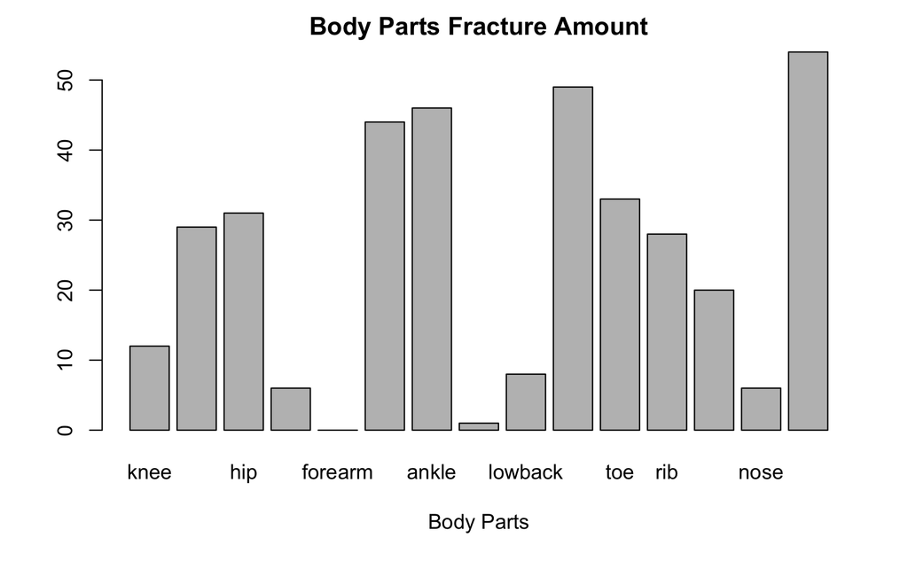

#### d) Age and Gender

| age | gender |
| --- | --- |
| 75Y | F |
| 8Y | F |
| 9 Y | M |
| NA | NA |
| 9Y | M |
| 12Y | F |
| 50 Y | F |
| 21 M | M |
| NA | NA |
| 77 Y | M |

[output cut: 990 more lines]

```r
for (i in 1:9999) {
  if (month_log[i]) {
   test$age[i] <- (as.numeric (str_extract(test$age[i], "\\d+")) )/12
  } else {
    test$age[i] <- as.numeric(test$age[i])
  }
  }
```

[output not shown]

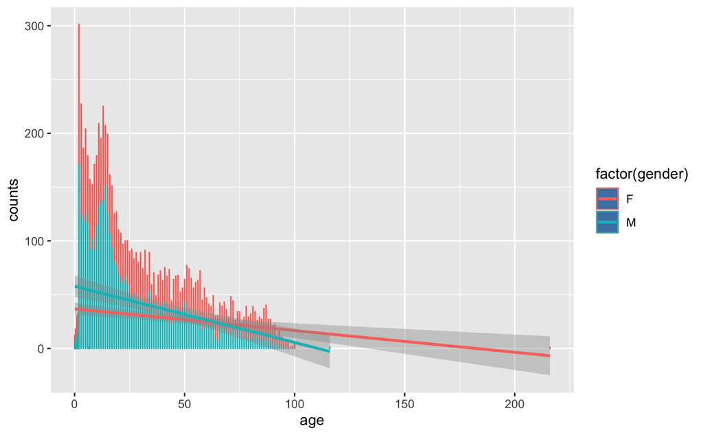

- “**75 YOM**, FELL DOWN STAIRS, FRACTURE LEG”: A 75 year old male.
- "**21MOF** FINGER SHUT IN WINDOW AT HOME;NAILBED INJURY: A 21 month-old female child.
- “DX:AVULSION OF SKIN-**50YOF**-CUT THUMB WITH SCISSORS TONIGHT-OPENING A BOX”: A 50 year old female.
- “LEFT ELBOW CONTUSION,RT SHIN LAC.PT WAS ICE SKATING AND FELL.”: No information about age or gender.

You are generally looking for a pattern with a number (*age*), something to indicate the *units*, e.g. YO or YR for years old, or MO for months old, and a character that identifies the *gender*. So, I suggest to think of a pattern that combines these three parts.

Create variables for age and gender (make sure to convert months to years when necessary). How many males and females are in the data? Provide a line graph of the number of injuries (y-axis) vs age (x-axis) disaggregated by gender.